# StepReg: Stepwise Regression Analysis

Junhui Li, Kai Hu, Xiaohuan Lu and Lihua Julie Zhu

University of Massachusset Chan Medical School, Worcester, USA  
Clark University, Worcester, USA

3 February 2025

#### Abstract

The StepReg package, developed for exploratory model building tasks, offers support across diverse scenarios. It facilitates model construction for various response variable types, including continuous (linear regression), binary (logistic regression), and time-to-event (Cox regression), among others. StepReg encompasses all commonly used model selection strategies, including forward selection, backward elimination, bidirectional elimination, and best subsets. Notably, it offers flexibility in selection metrics, accommodating both information criteria (AIC, BIC, etc.) and significance level cutoffs. This vignettes provide numerous examples showcasing the effective utilization of StepReg for model development in diverse contexts. Furthermore, it delves into considerations for selecting appropriate strategies and metrics, empowering users to make informed decisions throughout the modeling process.

#### Package

StepReg 1.5.7

# 1 Introduction

Model selection is the process of choosing the most relevant features from a set of candidate variables. This procedure is crucial because it ensures that the final model is both accurate and interpretable while being computationally efficient and avoiding overfitting. Stepwise regression algorithms iteratively add or remove features from the model based on certain criteria (e.g., significance level or P-value, information criteria like AIC or BIC, etc.). The process continues until no further improvements can be made according to the chosen criterion. At the end of the stepwise procedure, you’ll have a final model that includes the selected features and their coefficients.

# 2 Quick demo

The following example selects an optimal linear regression model with the `mtcars` dataset.

```r
#library(StepReg)
devtools::load_all("~/dropbox/Project/UMMS/Github/JunhuiLi1017/StepReg")
data(mtcars)
formula <- mpg ~ .
res <- stepwise(formula = formula,
                data = mtcars,
                type = "linear",
                include = c("qsec"),
                strategy = "bidirection",
                metric = c("AIC"))
```

Breakdown of the parameters:

- `formula`: specifies the dependent and independent variables
- `type`: specifies the regression category, depending on your data, choose from “linear”, “logit”, “cox”, etc.
- `include`: specifies the variables that must be in the final model
- `strategy`: specifies the stepwise strategy, choose from “forward”, “backward”, “bidirection”, “subset”
- `metric`: specifies the model fit evaluation metric, choose one or more from “AIC”, “AICc”, “BIC”, “SL”, etc.

The output consists of final model, which can be viewed using:

```r
res
```

```
$bidirection
$bidirection$AIC

Call:
lm(formula = mpg ~ 1 + qsec + wt + am, data = data, weights = NULL)

Coefficients:
(Intercept)         qsec           wt           am
      9.618        1.226       -3.917        2.936
```

You can further explore the results with generic functions such as `summary()`, `coeff()`, and others. For example:

```r
summary(res$bidirection$AIC)
```

```
Call:
lm(formula = mpg ~ 1 + qsec + wt + am, data = data, weights = NULL)

Residuals:
    Min      1Q  Median      3Q     Max
-3.4811 -1.5555 -0.7257  1.4110  4.6610

Coefficients:
            Estimate Std. Error t value Pr(>|t|)
(Intercept)   9.6178     6.9596   1.382 0.177915
qsec          1.2259     0.2887   4.247 0.000216 ***
wt           -3.9165     0.7112  -5.507 6.95e-06 ***
am            2.9358     1.4109   2.081 0.046716 *
---
Signif. codes:  0 '***' 0.001 '**' 0.01 '*' 0.05 '.' 0.1 ' ' 1

Residual standard error: 2.459 on 28 degrees of freedom
Multiple R-squared:  0.8497,    Adjusted R-squared:  0.8336
F-statistic: 52.75 on 3 and 28 DF,  p-value: 1.21e-11
```

You can also visualize the variable selection procedures with:

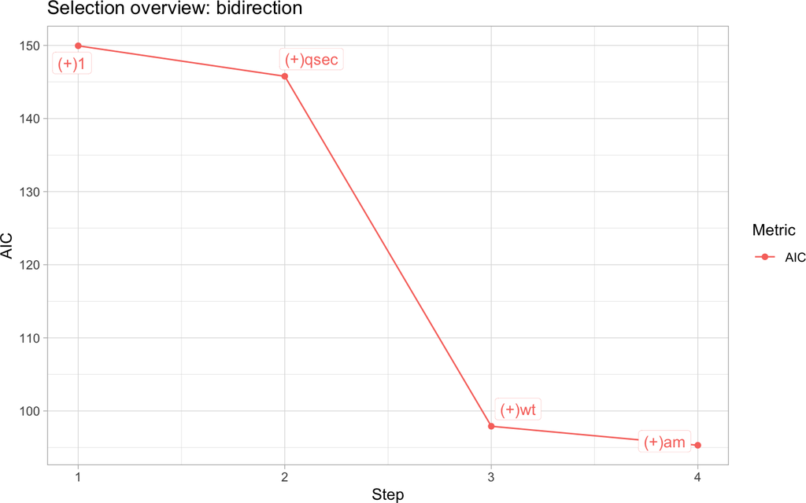

```r
plot(res, strategy = "bidirection", process = "overview")
```

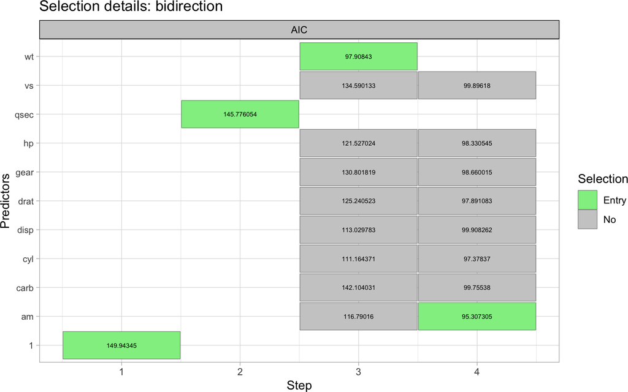

```r
plot(res, strategy = "bidirection", process = "details")
```

The `(+)1` refers to original model with intercept being added, `(+)` indicates variables being added to the model while `(-)` means variables being removed from the model.

Additionally, you can generate reports of various formats with:

```r
report(res, report_name = "path_to/demo_res", format = "html")
```

Replace `"path_to/demo_res"` with desired output file name, the suffix `".html"` will be added automatically. For detailed examples and more usage, refer to section 4 and 5.

# 3 Key features

## 3.1 Regression categories

**StepReg** supports multiple types of regressions, including *linear*, *logit*, *cox*, *poisson*, and *gamma* regressions. These methods primarily vary by the type of response variable, which are summarized in the table below. Additional regression techniques can be incorporated upon user requests.

Table 1: Common regression categories

| Regression | Reponse |
| --- | --- |
| linear | continuous |
| logit | binary |
| cox | time-to-event |
| poisson | count |
| gamma | continuous and positively skewed |

## 3.2 Model selection strategies

Model selection aims to identify the subset of independent variables that provide the best predictive performance for the response variable. Both stepwise regression and best subsets approaches are implemented in StepReg. For stepwise regression, there are mainly three methods: *Forward Selection*, *Backward Elimination*, *Bidirectional Elimination*.

Table 2: Model selection strategy

| Strategy | Description |
| --- | --- |
| Forward Selection | In forward selection, the algorithm starts with an empty model (no predictors) and adds in variables one by one. Each step tests the addition of every possible predictor by calculating a pre-selected … |
| Backward Elimination | In backward elimination, the algorithm starts with a full model (all predictors) and deletes variables one by one. Each step test the deletion of every possible predictor by calculating a pre-selected… |
| Bidirectional Elimination | Bidirectional elimination is essentially a forward selection procedure combined with backward elimination at each iteration. Each iteration starts with a forward selection step that adds in predictors… |
| Best Subsets | Stepwise algorithms add or delete one predictor at a time and output a single model without evaluating all candidates. Therefore, it is a relatively simple procedure that only produces one model. In c… |

## 3.3 Selection metrics

Various *selection metrics* can be used to guide the process of adding or removing predictors from the model. These metrics help to determine the importance or significance of predictors in improving the model fit. In StepReg, selection metrics include two categories: *Information Criteria* and *Significance Level* of the coefficient associated with each predictor. *Information Criteria* is a means of evaluating a model’s performance, which balances model fit with complexity by penalizing models with a higher number of parameters. Lower *Information Criteria* values indicate a better trade-off between model fit and complexity. Note that when evaluating different models, it is important to compare them within the same *Information Criteria* framework rather than across multiple Information Criteria. For example, if you decide to use AIC, you should compare all models using AIC. This ensures consistency and fairness in model comparison, as each Information Criterion has its own scale and penalization factors. In practice, multiple metrics have been proposed, the ones supported by StepReg are summarized below.

Importantly, given the discrepancies in terms of the precise definitions of each metric, StepReg mirrors the formulas adopted by [SAS](https://documentation.sas.com/doc/en/statcdc/14.2/statug/statug_glmselect_details15.htm) for *univariate multiple regression (UMR)* except for HQ, IC(1), and IC(3/2). A subset of the UMR can be easily extended to *multivariate multiple regression (MMR)*, which are indicated in the following table.

Table 3: Statistics in selection metric

| Statistic | Meanings |
| --- | --- |
| ${n}$ | Sample Size |
| ${p}$ | Number of parameters including the intercept |
| ${q}$ | Number of dependent variables |
| $\sigma^2$ | Estimate of pure error variance from fitting the full model |
| ${SST}$ | Total sum of squares corrected for the mean for the dependent variable, which is a numeric value for UMR and a matrix for multivariate regression |
| ${SSE}$ | Error sum of squares, which is a numeric value for UMR and a matrix for multivariate regression |
| $\text{LL}$ | The natural logarithm of likelihood |
| ${\| \|}$ | The determinant function |
| $\ln()$ | The natural logarithm |

Table 4: Abbreviation, Definition, and Formula of the Selection Metric for Linear, Logit, Cox, Possion, and Gamma regression

| Abbreviation | Definition | Formula |  |
| --- | --- | --- | --- |
|  |  | linear | logit, cox, poisson and gamma |
| AIC | Akaike’s Information Criterion | $n\ln\left(\frac{\|\text{SSE}\|}{n}\right) + 2pq + n + q(q+1)$ (Clifford M. Hurvich 1989; Al-Subaihi 2002)$^1$ | $-2\text{LL} + 2p$ (Darlington 1968; George G. Judge 1985) |
| AICc | Corrected Akaike’s Information Criterion | $n\ln\left(\frac{\|\text{SSE}\|}{n}\right) + \frac{nq(n+p)}{n-p-q-1}$ (Clifford M. Hurvich 1989; Edward J. Bedrick 1994)$^2$ | $-2\text{LL} + \frac{n(n+p)}{n-p-2}$ (Clifford M. Hurvich 1989) |
| BIC | Sawa Bayesian Information Criterion | $n\ln\left(\frac{SSE}{n}\right) + 2(p+2)o - 2o^2, o = \frac{n\sigma^2}{SSE}$ (Sawa 1978; George G. Judge 1985) not available for MMR | not available |
| Cp | Mallows’ Cp statistic | $\frac{SSE}{\sigma^2} + 2p - n$ (Mallows 1973; Hocking 1976) not available for MMR | not available |
| HQ | Hannan and Quinn Information Criterion | $n\ln\left(\frac{\|\text{SSE}\|}{n}\right) + 2pq\ln(\ln(n))$ (E. J. Hannan 1979; Allan D R McQuarrie 1998; Clifford M. Hurvich 1989) | $-2\text{LL} + 2p\ln(\ln(n))$ (E. J. Hannan 1979) |
| IC(1) | Information Criterion with Penalty Coefficient Set to 1 | $n\ln\left(\frac{\|\text{SSE}\|}{n}\right) + p$ (J. A. Nelder 1972; A. F. M. Smith 1980) not available for MMR | $-2\text{LL} + p$ (J. A. Nelder 1972; A. F. M. Smith 1980) |
| IC(3/2) | Information Criterion with Penalty Coefficient Set to 3/2 | $n\ln\left(\frac{\|\text{SSE}\|}{n}\right) + \frac{3}{2}p$ (A. F. M. Smith 1980) not available for MMR | $-2\text{LL} + \frac{3}{2}p$ (A. F. M. Smith 1980) |
| SBC | Schwarz Bayesian Information Criterion | $n\ln\left(\frac{\|\text{SSE}\|}{n}\right) + pq \ln(n)$ (Clifford M. Hurvich 1989; Schwarz 1978; George G. Judge 1985; Al-Subaihi 2002) not available for MMR | $-2\text{LL} + p\ln(n)$ (Schwarz 1978; George G. Judge 1985) |
| SL | Significance Level (pvalue) | $\textit{F test}$ for UMR and $\textit{Approximate F test}$ for MMR | Forward: LRT and Rao Chi-square test (logit, poisson, gamma); LRT (cox); Backward: Wald test |
| adjRsq | Adjusted R-square statistic | $1 - \frac{(n-1)(1-R^2)}{n-p}$, where $R^2=1 - \frac{SSE}{SST}$ (Darlington 1968; George G. Judge 1985) not available for MMR | not available |

<sup>1</sup> Unsupported AIC formula (which does not affect the selection process as it only differs by constant additive and multiplicative factors): $AIC=n\ln\left(\frac{SSE}{n}\right) + 2p$ (Darlington 1968; George G. Judge 1985)  
<sup>2</sup> Unsupported AICc formula (which does not affect the selection process as it only differs by constant additive and multiplicative factors): $AICc=\ln\left(\frac{SSE}{n}\right) + 1 + \frac{2(p+1)}{n-p-2}$ (Allan D R McQuarrie 1998)

No metric is necessarily optimal for all datasets. The choice of them depends on your data and research goals. We recommend using multiple metrics simultaneously, which allows the selection of the best model based on your specific needs. Below summarizes general guidance.

- AIC: AIC works by penalizing the inclusion of additional variables in a model. The lower the AIC, the better performance of the model. AIC does not include sample size in penalty calculation, and it is optimal in minimizing the mean square error of predictions (Mark J. Brewer 2016).
- AICc: AICc is a variant of AIC, which works better for small sample size, especially when `numObs / numParam < 40` (Kenneth P. Burnham 2002).
- Cp: Cp is used for linear models. It is equivalent to AIC when dealing with Gaussian linear model selection.
- IC(1) and IC(3/2): IC(1) and IC(3/2) have 1 and 3/2 as penalty factors respectively, compared to 2 used by AIC. As such, IC(1) turns to return a complex model with more variables that may suffer from overfitting issues.
- BIC and SBC: Both BIC and SBC are variants of Bayesian Information Criterion. The main distinction between BIC/SBC and AIC lies in the magnitude of the penalty imposed: BIC/SBC are more parsimonious when penalizing model complexity, which typically results to a simpler model (SAS Institute Inc 2018; Sawa 1978; Clifford M. Hurvich 1989; Schwarz 1978; George G. Judge 1985; Al-Subaihi 2002).

The precise definitions of these criteria can vary across literature and in the SAS environment. Here, BIC aligns with the definition of the Sawa Bayesion Information Criterion as outlined in [SAS](https://documentation.sas.com/doc/en/pgmsascdc/9.4_3.3/statug/statug_glmselect_syntax07.htm) documentation, while SBC corresponds to the Schwarz Bayesian Information Criterion. According to Richard’s [post](https://www.linkedin.com/pulse/aicbic-model-selection-richard-randa/), whereas AIC often favors selecting overly complex models, BIC/SBC prioritize a small models. Consequently, when dealing with a limited sample size, AIC may seem preferable, whereas BIC/SBC tend to perform better with larger sample sizes.

- HQ: HQ is an alternative to AIC, differing primarily in the method of penalty calculation. However, HQ has remained relatively underutilized in practice (Kenneth P. Burnham 2002).
- adjRsq: The adjusted R-squared (adj-R²) seeks to overcome the limitation of R-squared in model selection by considering the number of predictors. It serves a similar purpose to information criteria, as both methods compare models by weighing their goodness of fit against the number of parameters. However, information criteria are typically regarded as superior in this context (Stevens 2016).
- SL: SL stands for Significance Level (P-value), embodying a distinct approach to model selection in contrast to information criteria. The SL method operates by calculating a P-value through specific hypothesis testing. Should this P-value fall below a predefined threshold, such as 0.05, one should favor the alternative hypothesis, indicating that the full model significantly outperforms the reduced model. The effectiveness of this method hinges upon the selection of the P-value threshold, wherein smaller thresholds tend to yield simpler models.

## 3.4 Multicollinearity

This [blog](https://statisticsbyjim.com/regression/multicollinearity-in-regression-analysis/) by Jim Frost gives an excellent overview of multicollinearity and when it is necessary to remove it.

Simply put, a dataset contains multicollinearity when input predictors are correlated. When multicollinearity occurs, the interpretability of predictors will be badly affected because changes in one input variable lead to changes in other input variables. Therefore, it is hard to individually estimate the relationship between each input variable and the dependent variable.

Multicollinearity can dramatically reduce the precision of the estimated regression coefficients of correlated input variables, making it hard to find the correct model. However, as Jim pointed out, “Multicollinearity affects the coefficients and p-values, but it does not influence the predictions, precision of the predictions, and the goodness-of-fit statistics. If your primary goal is to make predictions, and you don’t need to understand the role of each independent variable, you don’t need to reduce severe multicollinearity.”

In StepReg, [QC Matrix Decomposition](https://towardsdatascience.com/qr-matrix-factorization-15bae43a6b2#:~:text=The%20QR%20matrix%20decomposition%20allows%20one%20to%20express%20a%20matrix,zero%2C%20it%20is%20also%20invertible.) is performed ahead of time to detect and remove input variables causing multicollinearity.

# 4 StepReg output

StepReg provides multiple functions for summarizing the model building results. The function `stepwise()` generates a list of data frame that describe the feature selection steps and the final model. To facilitate collaborations, you can redirect the data frame into various formats such as “xlsx”, “html”, “docx”, etc. with the function `report()`. Furthermore, you can easily compare the variable selection procedures for multiple selection metrics by visualizing the steps with the function `plot()`. Details see below.

Depending on the number of selected regression strategies and metrics, you can expect to receive optimal models from `stepwise()`. more functions like `summary()`, `coeff()`, `residuals()`, `fitted()` can be employed to each elements of the output.

You can save the stepwise arguments, variables class, stepwise process overview/details, and voted models in different format like “xlsx”, “docx”, “html”, “pptx”, and others, facilitating easy sharing. Of note, the suffix will be automatically added to the `report_name`. For instance, the following example generates both “results.xlsx” and “results.docx” reports.

```r
report(res, report_name = "results", format = c("xlsx", "docx"))
```

# 5 Use cases

Please choose the regression model that best suits the type of response variable. For detailed guidance, see section 3.1. Below, we present various examples utilizing different models tailored to specific datasets.

## 5.1 Linear regression with the *mtcars* dataset

In this section, we’ll demonstrate how to perform linear regression analysis using the [mtcars](https://stat.ethz.ch/R-manual/R-devel/library/datasets/html/mtcars.html) dataset, showcasing different scenarios with varying numbers of predictors and dependent variables. We set `type = "linear"` to direct the function to perform linear regression.

**Description of the `mtcars` dataset**

The `mtcars` is a classic dataset in statistics and is included in the base R installation. It was sourced from the 1974 *Motor Trend* US magazine, comprising 32 observations on 11 variables. Here’s a brief description of the variables included:

1. mpg: miles per gallon (fuel efficiency)
2. cyl: number of cylinders
3. disp: displacement (engine size) in cubic inches
4. hp: gross horsepower
5. drat: rear axle ratio
6. wt: weight (in thousands of pounds)
7. qsec: 1/4 mile time (in seconds)
8. vs: engine type (0 = V-shaped, 1 = straight)
9. am: transmission type (0 = automatic, 1 = manual)
10. gear: number of forward gears
11. carb: number of carburetors

**Why choose linear regression**

Linear regression is an ideal choice for analyzing the `mtcars` dataset due to its inclusion of continuous variables like “mpg”, “hp”, or “weight”, which can serve as response variables. Furthermore, the dataset exhibits potential linear relationships between the response variable and other variables.

### 5.1.1 Example1: single dependent variable (“mpg”)

In this example, we employ “forward” strategy with “AIC” as the selection criteria. Additionally, we specify using the `include` argument that “disp”, “cyl” always be included in the model.

```r
data(mtcars)

formula <- mpg ~ .
res1 <- stepwise(formula = formula,
                 data = mtcars,
                 type = "linear",
                 include = c("disp", "cyl"),
                 strategy = "forward",
                 metric = "AIC")
res1
```

```
$forward
$forward$AIC

Call:
lm(formula = mpg ~ 1 + disp + cyl + wt + hp, data = data, weights = NULL)

Coefficients:
(Intercept)         disp          cyl           wt           hp
   40.82854      0.01160     -1.29332     -3.85390     -0.02054
```

To visualize the selection process:

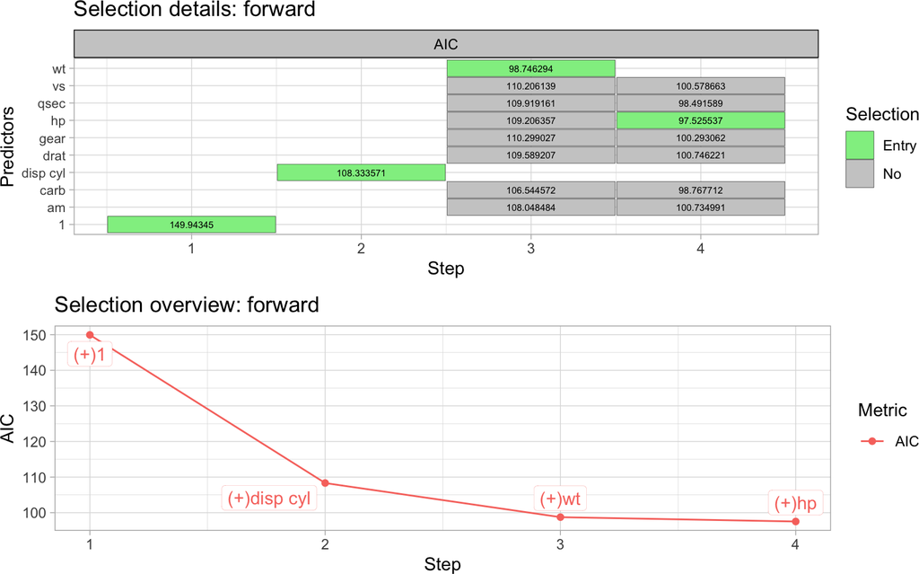

```r
plot_list <- list()
plot_list[["forward"]][["details"]] <- plot(res1, process = "details")
plot_list[["forward"]][["overview"]] <- plot(res1, process = "overview")
cowplot::plot_grid(plotlist = plot_list$forward, ncol = 1)
```

To exclude the intercept from the model, adjust the formula as follows:

```r
formula <- mpg ~ . + 0
```

```r
formula <- mpg ~ . - 1
```

To limit the model to a specific subset of predictors, adjust the formula as follows, which will only consider “cyp”, “disp”, “hp”, “wt”, “vs”, and “am” as the predictors.

```r
formula <- mpg ~ cyl + disp + hp + wt + vs + am + 0
```

Another way is to use minus symbol(`"-"`) to exclude some predictors for variable selection. For example, include all variables except “disp”, “wt”, and intercept.

```r
formula <- mpg ~ . - 1 - disp - wt
```

You can simultaneously provide multiple selection strategies and metrics. For example, the following code snippet employs both “forward” and “backward” strategies using metrics “AIC”, “BIC”, and “SL”. It’s worth mentioning that when “SL” is specified, you may also want to set the significance level for entry (“sle”) and stay (“sls”), both of which default to 0.15.

```r
formula <- mpg ~ .
res2 <- stepwise(formula = formula,
                 data = mtcars,
                 type = "linear",
                 strategy = c("forward", "backward"),
                 metric = c("AIC", "BIC", "SL"),
                 sle = 0.05,
                 sls = 0.05)
res2
```

```
$forward
$forward$AIC

Call:
lm(formula = mpg ~ 1 + wt + cyl + hp, data = data, weights = NULL)

Coefficients:
(Intercept)           wt          cyl           hp
   38.75179     -3.16697     -0.94162     -0.01804


$forward$BIC

Call:
lm(formula = mpg ~ 1 + wt + cyl, data = data, weights = NULL)

Coefficients:
(Intercept)           wt          cyl
     39.686       -3.191       -1.508


$forward$SL

Call:
lm(formula = mpg ~ 1 + wt + cyl, data = data, weights = NULL)

Coefficients:
(Intercept)           wt          cyl
     39.686       -3.191       -1.508



$backward
$backward$AIC

Call:
lm(formula = mpg ~ 1 + wt + qsec + am, data = data, weights = NULL)

Coefficients:
(Intercept)           wt         qsec           am
      9.618       -3.917        1.226        2.936


$backward$BIC

Call:
lm(formula = mpg ~ 1 + wt + qsec + am, data = data, weights = NULL)

Coefficients:
(Intercept)           wt         qsec           am
      9.618       -3.917        1.226        2.936


$backward$SL

Call:
lm(formula = mpg ~ 1 + wt + qsec + am, data = data, weights = NULL)

Coefficients:
(Intercept)           wt         qsec           am
      9.618       -3.917        1.226        2.936
```

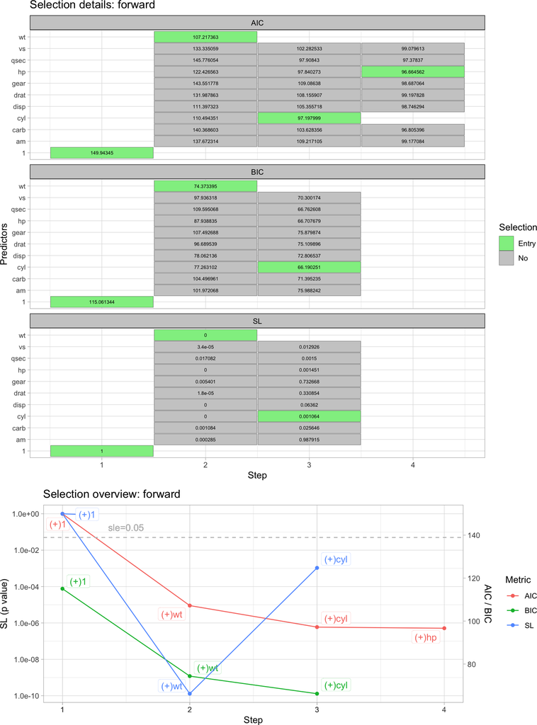

```r
plot_list <- setNames(
  lapply(c("forward", "backward"),function(i){
    setNames(
      lapply(c("details","overview"),function(j){
        plot(res2,strategy=i,process=j)
    }),
    c("details","overview")
    )
  }),
  c("forward", "backward")
)

cowplot::plot_grid(plotlist = plot_list$forward, ncol = 1, rel_heights = c(2, 1))
```

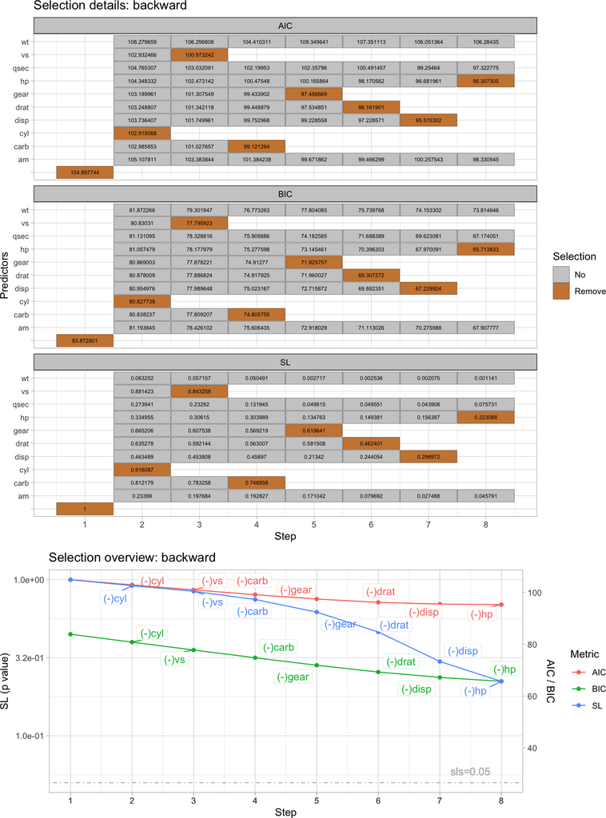

```r
cowplot::plot_grid(plotlist = plot_list$backward, ncol = 1, rel_heights = c(2, 1))
```

### 5.1.2 Example2: multivariate regression (“mpg” and “drat”)

In this scenario, there are two dependent variables, “mpg” and “drat”. The model selection aims to identify the most influential predictors that affect both variables.

```r
formula <- cbind(mpg, drat) ~ . + 0
res3 <- stepwise(formula = formula,
                 data = mtcars,
                 type = "linear",
                 strategy = "bidirection",
                 metric = c("AIC", "HQ"))
res3
```

```
$bidirection
$bidirection$AIC

Call:
lm(formula = cbind(mpg, drat) ~ 0 + gear + qsec + wt + am, data = data,
    weights = NULL)

Coefficients:
      mpg       drat
gear   0.48799   0.38197
qsec   1.53717   0.11809
wt    -3.29543  -0.02583
am     3.51269   0.38752


$bidirection$HQ

Call:
lm(formula = cbind(mpg, drat) ~ 0 + gear + qsec + wt + am, data = data,
    weights = NULL)

Coefficients:
      mpg       drat
gear   0.48799   0.38197
qsec   1.53717   0.11809
wt    -3.29543  -0.02583
am     3.51269   0.38752
```

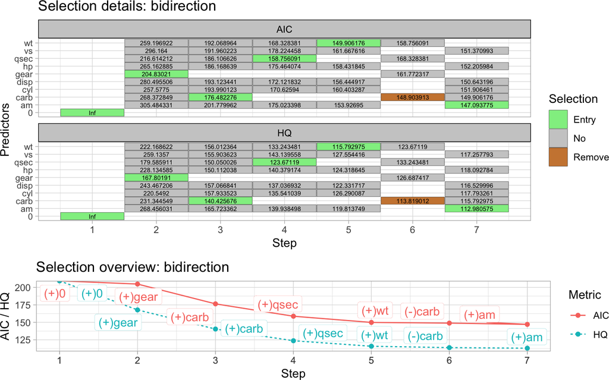

```r
plot_list <- setNames(
  lapply(c("bidirection"),function(i){
    setNames(
      lapply(c("details","overview"),function(j){
        plot(res3,strategy=i,process=j)
    }),
    c("details","overview")
    )
  }),
  c("bidirection")
)

cowplot::plot_grid(plotlist = plot_list$bidirection, ncol = 1, rel_heights = c(2, 1))
```

## 5.2 Logistic regression with the *remission* dataset

In this example, we’ll showcase logistic regression using the `remission` dataset. By setting `type = "logit"`, we instruct the function to perform logistic regression.

**Description of the `remission` dataset**

The [remission](https://online.stat.psu.edu/stat501/book/export/html/1011) dataset, obtained from the online course STAT501 at Penn State University, has been integrated into StepReg. It consists of 27 observations across seven variables, including a binary variable named “remiss”:

1. remiss: whether leukemia remission occurred, a value of 1 indicates occurrence while 0 means non-occurrence
2. cell: cellularity of the marrow clot section
3. smear: smear differential percentage of blasts
4. infil: percentage of absolute marrow leukemia cell infiltrate
5. li: percentage labeling index of the bone marrow leukemia cells
6. blast: the absolute number of blasts in the peripheral blood
7. temp: the highest temperature before the start of treatment

**Why choose logistic regression**

Logistic regression effectively captures the relationship between predictors and a categorical response variable, offering insights into the probability of being assigned into specific response categories given a set of predictors. It is suitable for analyzing binary outcomes, such as the remission status (“remiss”) in the `remission` dataset.

### 5.2.1 Example1: using “forward” strategy

In this example, we employ a “forward” strategy with “AIC” as the selection criteria, while force ensuring that the “cell” variable is included in the model.

```r
data(remission)

formula <- remiss ~ .
res4 <- stepwise(formula = formula,
                 data = remission,
                 type = "logit",
                 include= "cell",
                 strategy = "forward",
                 metric = "AIC")
```

```
[1] "There was an error message."
```

```r
res4
```

```
$forward
$forward$AIC

Call:  glm(formula = remiss ~ 1 + cell + li + temp, family = "binomial",
    data = data, weights = NULL)

Coefficients:
(Intercept)         cell           li         temp
     67.634        9.652        3.867      -82.074

Degrees of Freedom: 26 Total (i.e. Null);  23 Residual
Null Deviance:      34.37
Residual Deviance: 21.95    AIC: 29.95
```

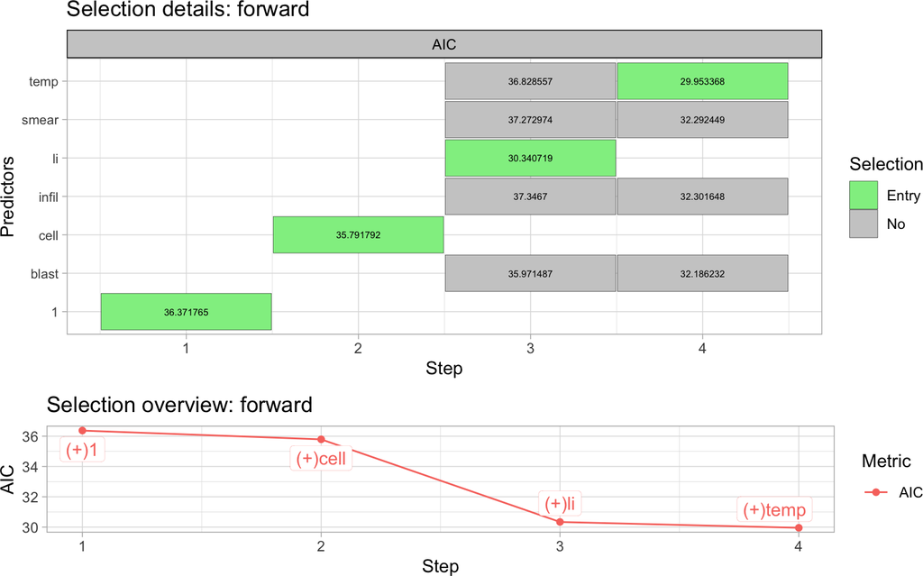

```r
plot_list <- setNames(
  lapply(c("forward"),function(i){
    setNames(
      lapply(c("details","overview"),function(j){
        plot(res4,strategy=i,process=j)
    }),
    c("details","overview")
    )
  }),
  c("forward")
)
cowplot::plot_grid(plotlist = plot_list$forward, ncol = 1, rel_heights = c(2, 1))
```

### 5.2.2 Example2: using “subset” strategy

In this example, we employ a “subset” strategy, utilizing “SBC” as the selection criteria while excluding the intercept. Meanwhile, we set `best_n = 3` to restrict the output to the top 3 models for each number of variables.

```r
data(remission)

formula <- remiss ~ . + 0
res5 <- stepwise(formula = formula,
                  data = remission,
                  type = "logit",
                  strategy = "subset",
                  metric = "SBC",
                  best_n = 3)
```

```
[1] "There was an error message."
```

```r
res5
```

```
$subset
$subset$SBC

Call:  glm(formula = remiss ~ 0 + li + temp, family = "binomial", data = data,
    weights = NULL)

Coefficients:
    li    temp
 2.942  -3.855

Degrees of Freedom: 27 Total (i.e. Null);  25 Residual
Null Deviance:      37.43
Residual Deviance: 25.86    AIC: 29.86
```

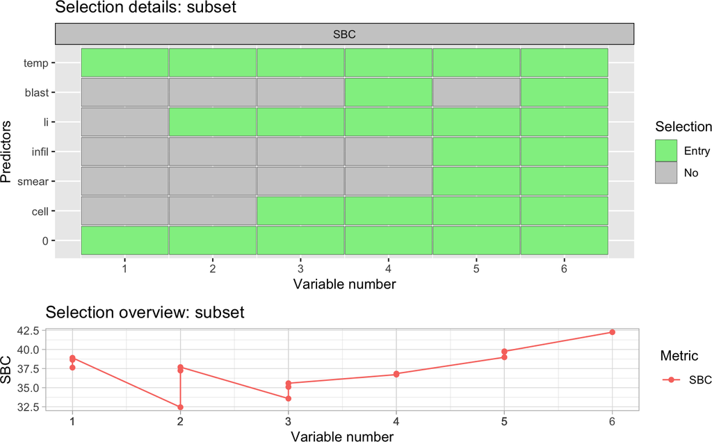

```r
plot_list <- setNames(
  lapply(c("subset"),function(i){
    setNames(
      lapply(c("details","overview"),function(j){
        plot(res5,strategy=i,process=j)
    }),
    c("details","overview")
    )
  }),
  c("subset")
)
cowplot::plot_grid(plotlist = plot_list$subset, ncol = 1, rel_heights = c(2, 1))
```

Here, the `0` in the above plot means that there is no intercept in the model.

## 5.3 Cox regression with the `lung` dataset

In this example, we’ll demonstrate how to perform Cox regression analysis using the [`lung`](https://stat.ethz.ch/R-manual/R-devel/library/survival/html/lung.html) dataset. By setting `type = "cox"`, we instruct the function to conduct Cox regression.

**Description of the `lung` dataset**

The `lung` dataset, available in the `"survival"` R package, includes information on survival times for 228 patients with advanced lung cancer. It comprises ten variables, among which the “status” variable codes for censoring status (1 = censored, 2 = dead), and the “time” variable denotes the patient survival time in days. To learn more about the dataset, use `?survival::lung`.

**Why choose Cox regression**

Cox regression, also termed the Cox proportional hazards model, is specifically designed for analyzing survival data, making it well-suited for datasets like `lung` that include information on the time until an event (e.g., death) occurs. This method accommodates censoring and assumes proportional hazards, enhancing its applicability to medical studies involving time-to-event outcomes.

### 5.3.1 Example1: using “forward” strategy

In this example, we employ a “forward” strategy with “AICc” as the selection criteria.

```r
library(dplyr)
library(survival)
# Preprocess:
lung <- survival::lung %>%
  mutate(sex = factor(sex, levels = c(1, 2))) %>% # make sex as factor
  na.omit() # get rid of incomplete records

formula  =  Surv(time, status) ~ .
res6 <- stepwise(formula = formula,
                 data = lung,
                 type = "cox",
                 strategy = "forward",
                 metric = "AICc")
res6
```

```
$forward
$forward$AICc
Call:
coxph(formula = Surv(time, status) ~ 0 + ph.ecog + sex + inst +
    wt.loss + ph.karno, data = data, weights = NULL, method = "efron")

              coef exp(coef)  se(coef)      z        p
ph.ecog   0.993224  2.699926  0.232115  4.279 1.88e-05
sex2     -0.571959  0.564419  0.198865 -2.876  0.00403
inst     -0.030042  0.970404  0.012931 -2.323  0.02016
wt.loss  -0.014800  0.985309  0.007664 -1.931  0.05348
ph.karno  0.021492  1.021725  0.011222  1.915  0.05547

Likelihood ratio test=30.44  on 5 df, p=1.208e-05
n= 167, number of events= 120
```

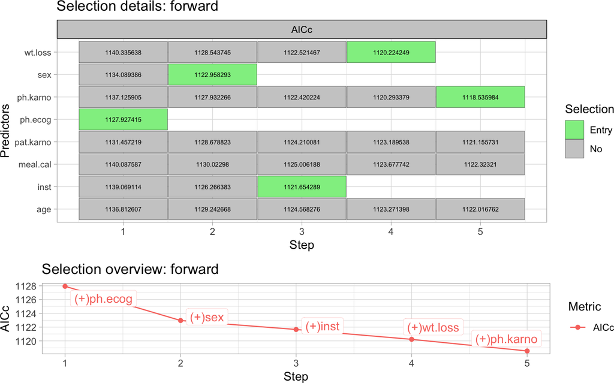

```r
plot_list <- setNames(
  lapply(c("forward"),function(i){
    setNames(
      lapply(c("details","overview"),function(j){
        plot(res6,strategy=i,process=j)
    }),
    c("details","overview")
    )
  }),
  c("forward")
)
cowplot::plot_grid(plotlist = plot_list$forward, ncol = 1, rel_heights = c(2, 1))
```